[OHI British Columbia](http://www.ohibc.org/) | [OHI Science](http://ohi-science.org) | [Citation policy](https://github.com/OHI-Science/ohiprep/releases)

# OHIBC: herring spawn index prep

Compiled on Thu Apr 6 14:20:14 2017 by ohara

```r
knitr::opts_chunk$set(fig.width = 6, fig.height = 4, fig.path = 'Figs/',
                      echo = TRUE, message = FALSE, warning = FALSE)

source('~/github/ohibc/src/R/common.R')  ### an OHIBC specific version of common.R

dir_git     <- '~/github/ohibc'
dir_spatial <- file.path(dir_git, 'prep/spatial')  ### github: general buffer region shapefiles
dir_anx     <- file.path(dir_M, 'git-annex/bcprep')

### goal specific folders and info
goal     <- 'ao'
scenario <- 'v2017'
dir_goal <- file.path(dir_git, 'prep', goal, scenario)
dir_goal_anx <- file.path(dir_anx, goal, scenario)

### provenance tracking
library(provRmd); prov_setup()

### set up the default BC projection to be BC Albers
p4s_bcalb <- c('bcalb' = '+init=epsg:3005')
```

# 1 Summary

This data is incorporated into the OHI British Columbia First Nations Resource Access and Opportunities (AO) goal.

# 2 Data Source

**Time Range**: N/A

**Format**: CSV

# 3 Methods

## 3.1 Read in Herring Spawn data

### 3.1.1 Herring Spawn Index

Herring spawn data is available as Spawn Habitat Index values calculated for sub-regions across BC from 1920s, 30s, and 40s to 2016.

- Data in text tables [here](http://www.pac.dfo-mpo.gc.ca/science/species-especes/pelagic-pelagique/herring-hareng/herspawn/tabsbkm2-eng.html)
- Documentation and background [here](http://www.pac.dfo-mpo.gc.ca/science/species-especes/pelagic-pelagique/herring-hareng/hertags/pdf/project-eng.pdf)

The documentation provides great detail, and some important notes are excerpted below.

> Based on detailed examination of the original records, it is clear that the overwhelming majority of the fishery officers and divers who report on herring spawns, have done it in a dedicated, professional and competent manner, often with detailed comments and charts accompanying the records. There are undoubtedly some errors in individual records, but usually the impact of such errors is diminished because of the relatively large number of records available for most locations. Furthermore, these records were gathered by hundreds of different individuals over a 75 year period. Within any single location, there were at least several different data recorders, and often many more over the years. So it is unlikely to expect a continuous run of poor data records.

> There are, nevertheless, two kinds of systematic errors in these records which should be mentioned. The first appears to be a time-dependent trend for fishery officers to under-estimate the width of egg depositions. This occurred mainly in the earlier years, when it was generally believed that most of the spawn was confined to the intertidal zone. It has not been until relatively recent times that the significance of the subtidal fraction has been fully appreciated (Haegele et al. 1983). Also, there has been systematic changes (see Hay and Kronlund 1987) in the measurement of spawn density over the years, starting with a 1 to 5 “intensity” or categorical scale from 1928 to 1950, to a 1 to 9 “intensity” scale from 1951 to 1982 and then eventually to an egg layer measurement from 1977 to the present date. Each of these intensity measurements have been converted to average egg layers in the database. Previously, a spawn coefficient (Hay and Kronlund 1987) was applied to correct for these time-dependent errors. An area-specific coefficient was calculated by the mean of the product of spawn width and intensity, pooled at the herring section geographic scale. Today, a similar correction is applied whereby the median of the product of spawn width and egg layer measurements are pooled by a range of discrete kilometre segments along the coastline. This coefficient is incorporated into a cumulative spawn index described below.

> **Spawn Habitat Index:** We have computed a cumulative spawn habitat index (SHI) to represent the combined, long-term frequency and magnitude of spawns along each kilometre of coastline over time. The index is simply a measure of shoreline utilization by spawning herring. This index should not be confused with the “spawn index” as applied to escapement, age-structure or more recently, catchage assessment models (Cleary et al. 2010-2012, Schweigert et al. 1993-2009 or Haist et al. 1984-1992). The cumulative Spawn Habitat Index is calculated by the sum of the product of each measured spawn length (m) and the median of the product of spawn width (m) and egg layers adjusted by percent cover and pooled geographically. Spawn width and egg layer measurements were pooled by a range of discrete, coastal shoreline kilometre segments, over all years (1928 to the current year) and reflect the bathymetric (depth and slope) and vegetative features (seaweed species compositions) of the spawning sites (area-specific spawn coefficient). The measured length (m) of shoreline that is utilized by spawners is considered the most reliable of the three, primary spawn measurements in terms of database completeness and consistency and has the most influence on the Spawn Habitat Index (SHI = Length x Spawn Coefficient) at a spawning area.

> … The only other kind of error in the records which can severely affect conclusions presented in these analyses, is that of incompleteness. It is clear that for some locations, records were not collected systematically each year. Sometimes, problems with field communications, equipment and weather resulted in data deficiencies. It is also known that many small, but observable spawns, do not reach the doorstep of the database while others do. These spawns may be important from a habitat perspective but are not high on the list from a stock assessment viewpoint, where survey priorities are set.

#### 3.1.1.1 extracting data from web

This link is the gateway to the various spawn habitat index pages: * http://www.pac.dfo-mpo.gc.ca/science/species-especes/pelagic-pelagique/herring-hareng/herspawn/tabsbkm2-eng.html * source for this page shows that the links are within [this page in the bottom frame](http://www.pac.dfo-mpo.gc.ca/science/species-especes/pelagic-pelagique/herring-hareng/herspawn/tabindex-eng.html#2). * scan the link page via XML to extract links for the various sub-area pages. * update - not XML, just HTML… extract from the anchor tags

```r
library(xml2); library(XML)

links_url <- 'http://www.pac.dfo-mpo.gc.ca/science/species-especes/pelagic-pelagique/herring-hareng/herspawn/tabindex-eng.html#2'
shi_dir <- dirname(links_url)

links_html <- read_html(links_url) %>%
  htmlParse()

links_df_raw <- capture.output(links_html, file=NULL) %>%
  as.data.frame() %>%
  setNames('html_raw')

links_df <- links_df_raw %>%
  filter(str_detect(tolower(html_raw), 'reg[0-9]roll-eng|statist|section')) %>%
  mutate(html = str_replace_all(html_raw, '<[/]*li>|\\\r', ''),   ### get rid of list tags and \r tags
         html = str_replace_all(html, ' *---+.+', ''),
         link = str_extract(html, '(?<=href\\=\\").+(?=\\")'),
         link = ifelse(is.na(link), NA, file.path(shi_dir, link)),
         link_info = str_extract(html, '(?<=\\">).+')) %>%
  separate(link_info, c('link_area', 'area_name'), '</a>[-, ]*') %>%
  mutate(link_area = ifelse(is.na(link_area), html, link_area)) %>%
  select(-html_raw)

write_csv(links_df, file.path(dir_goal, 'int/shi_links.csv'))
```

```r
shi_data_file <- file.path(dir_goal, 'int/shi_data.csv')

if(!file.exists(shi_data_file)) {

  links_active <- read_csv(file.path(dir_goal, 'int/shi_links.csv')) %>%
    filter(!is.na(link) & str_detect(tolower(link_area), 'region|statist|section'))

  links_vec <- links_active$link %>%
    setNames(paste(links_active$link_area, links_active$area_name, sep = '~'))

  table_cols <- c('year', 'tot_records', 'spawn_hab_index',
                  'l_tot', 'w_mean', 'layers_mean', 'sst_wgt',
                  'date_mean', 'd_wgt', 'd_min', 'd_max',
                  'diver_survey_pct')

  shi_df <- lapply(links_vec, FUN = function(x) {
    ### x <- links_vec[1]
    y <- read.table(x, skip = 14, fill = TRUE, na.strings = '*') %>%
      setNames(table_cols) %>%
      mutate(year = as.integer(year),
             tot_records = as.integer(tot_records)) %>%
      filter(!is.na(year))
  }) %>%
    setNames(names(links_vec)) %>%
    bind_rows(.id = 'id') %>%
    separate(id, c('area', 'area_name'), '~')

  write_csv(shi_df, shi_data_file)

} else {

  git_prov(shi_data_file, 'output')

}
```

#### 3.1.1.2 Herring spawn index by rgn by year

Possible reference point: mean herring spawn index from 1940-1960? For each DFO larger region, let’s plot this. These are not OHIBC analysis regions.

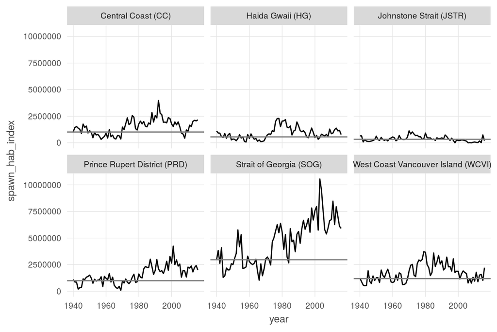

```r
shi_df <- read_csv(file.path(dir_goal, 'int/shi_data.csv'))

shi_rgn <- shi_df %>%
  filter(str_detect(area, 'Region')) %>%
  group_by(area) %>%
  mutate(area_name = str_replace_all(area_name, '((?<=\\))).+', ''),
         tmp = ifelse(year <= 1960, 1, NA),
         ref_shi = mean(spawn_hab_index * tmp, na.rm = TRUE)) %>%
  ungroup() %>%
  select(-tmp)

ggplot(shi_rgn, aes(x = year, y = spawn_hab_index, group = area)) +
  ggtheme_plot() +
  geom_line() +
  geom_hline(aes(yintercept = ref_shi), color = 'grey50') +
  facet_wrap( ~ area_name)
```

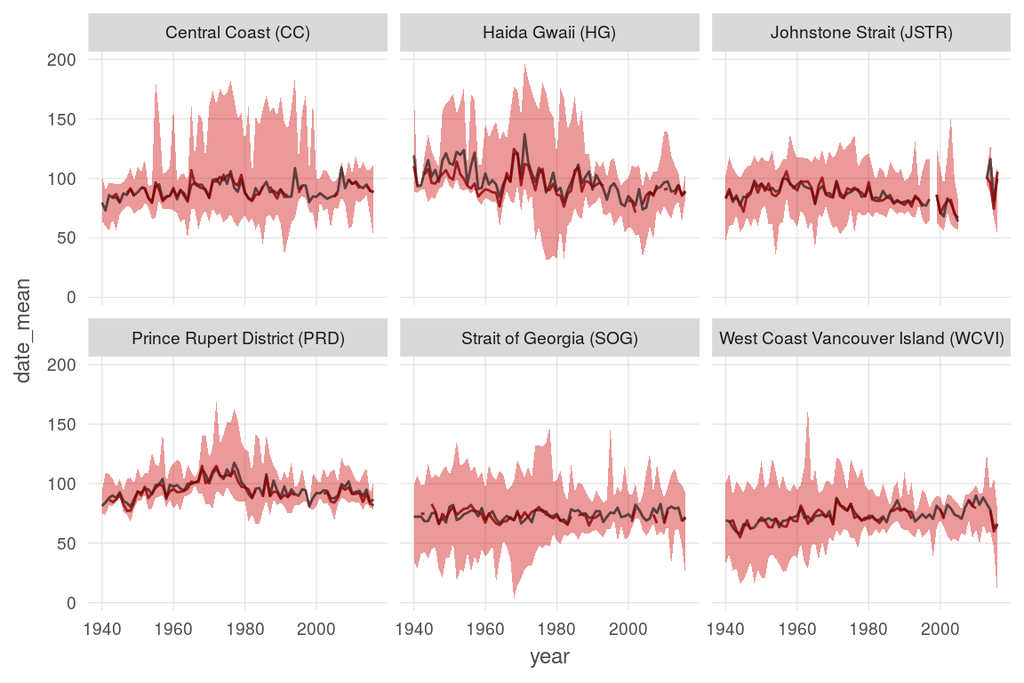

```r
ggplot(shi_rgn, aes(x = year, y = date_mean, group = area)) +
  ggtheme_plot() +
  geom_ribbon(aes(ymin = d_min, ymax = d_max), fill = 'red3', color = NA, alpha = .4) +
  geom_line(color = 'black', alpha = .6) +
  geom_line(aes(y = d_wgt), color = 'red4', alpha = .8) +
  facet_wrap( ~ area_name)
```

### 3.1.2 Spatialize Spawn Habitat Index data

Spawn sections do not correspond with PFMAs or PFMSAs. Instead, we will classify sections into OHIBC regions by inspecting the maps e.g. http://www.pac.dfo-mpo.gc.ca/science/species-especes/pelagic-pelagique/herring-hareng/herspawn/ccst_map-eng.html. For sections that appear to intersect multiple OHIBC regions, closer inspection (i.e. clicking on the section number on the map) reveals the distribution and sites of spawn within the region; using these, we can roughly estimate the proportion of spawn that falls into each intersecting OHIBC region.

```r
shi_df <- read_csv(file.path(dir_goal, 'int/shi_data.csv'))

shi_sec <- read_csv(file.path(dir_goal, 'raw/shi_sections.csv')) %>%
  select(-area_name) %>%
  distinct()

shi_ohibc <- shi_df %>%
  filter(str_detect(tolower(area), 'section')) %>%
  select(area, area_name, year, tot_records, spawn_hab_index) %>%
  distinct() %>%
  left_join(shi_sec, by = c('area')) %>%
  group_by(rgn_id, year) %>%
  summarize(shi_tot = sum(spawn_hab_index * rgn_wgt, na.rm = TRUE)) %>%
  ungroup() %>%
  left_join(get_rgn_names(), by = 'rgn_id')

write_csv(shi_ohibc, file.path(dir_goal, 'output/ao_spawn_hab_index.csv'))
```

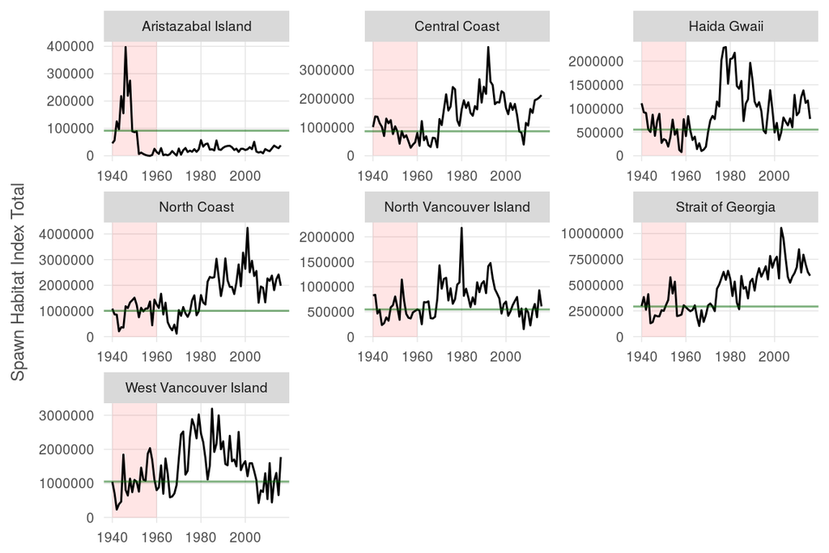

```r
shi_by_rgn <- read_csv(file.path(dir_goal, 'output/ao_spawn_hab_index.csv'))

ref_yrs <- c(1900:1960)

shi_ohibc <- shi_by_rgn %>%
  group_by(rgn_id) %>%
  mutate(tmp = ifelse(year %in% ref_yrs, 1, NA),
         ref_shi = mean(shi_tot * tmp, na.rm = TRUE)) %>%
  ungroup() %>%
  select(-tmp)

ggplot(shi_ohibc, aes(x = year, y = shi_tot, group = rgn_id)) +
  ggtheme_plot() +
  theme(axis.title.x = element_blank()) +
  annotate('rect', xmin=max(min(ref_yrs), min(shi_ohibc$year)), xmax=max(ref_yrs), ymin=0, ymax=Inf, fill = 'red', alpha = .1) +
  geom_line() +
  geom_hline(aes(yintercept = ref_shi), color = 'darkgreen', alpha = .5) +
  labs(y = 'Spawn Habitat Index Total') +
  facet_wrap( ~ rgn_name, scales = 'free')
```

### 3.1.3 Herring spawn SSB by year

Additionally, Karen Hunter of the DFO provided spawn data from 2005-2015 divided into PFMA subareas that may be useful to compare to the Spawn Habitat Index, though on its own, its utility is limited by the relatively short time series.

[figure not shown]

```r
data_file <- file.path(dir_anx, '_raw_data/dfo_khunter/d2016/fisheries',
                         'Herring Spawn Index_SSBbysection_coastwide_2005to2015.xlsx')

sheets <- readxl::excel_sheets(data_file)

hspawn_dfo_raw <- lapply(sheets, FUN = function(x) {
  # x <- sheets[1]
    capture.output( ### the read_excel function annoyingly prints crap to screen
      {
        y <- readxl::read_excel(data_file, sheet = x)
      },
      file = file.path(dir_goal, 'delete_this.txt')
    )
    unlink(file.path(dir_goal, 'delete_this.txt'))

    z <- y %>%
      setNames(tolower(names(.))) %>%
      rename(total_ssb = `total ssb (tonnes)`) %>%
      mutate(year = as.integer(year),
             total_ssb = as.integer(total_ssb)) %>%
      filter(!is.na(year)) %>%
      gather(area, ssb, everything(), -year, -contains('total')) %>%
      mutate(dfo_rgn = x)
    return(z)
  }) %>%
  bind_rows() %>%
  mutate(area = str_replace(area, '-', '') %>% as.integer())

shi_sec <- read_csv(file.path(dir_goal, 'raw/shi_sections.csv')) %>%
  select(-area_name) %>%
  mutate(area = str_replace(area, 'Section ', '') %>% as.integer())

hspawn_dfo_clean <- hspawn_dfo_raw %>%
  left_join(shi_sec, by = 'area')

write_csv(hspawn_dfo_clean, file.path(dir_goal_anx, 'int/hspawn_dfo_clean.csv'))

hspawn_dfo_summary <- hspawn_dfo_clean %>%
  group_by(rgn_id, year) %>%
  summarize(ssb_tot = sum(ssb * rgn_wgt, na.rm = TRUE)) %>%
  ungroup()


shi_ohibc_05_15 <- read_csv(file.path(dir_goal, 'output/ao_spawn_hab_index.csv')) %>%
  filter(year >= 2005 & year <= 2015) %>%
  full_join(hspawn_dfo_summary, by = c('year', 'rgn_id')) %>%
  group_by(rgn_id) %>%
  mutate(shi_rel = shi_tot / max(shi_tot),
         ssb_rel = ssb_tot / max(ssb_tot)) %>%
  ungroup()

ggplot(shi_ohibc_05_15, aes(x = year, y = shi_rel, group = rgn_id)) +
  ggtheme_plot() +
  theme(axis.title.x = element_blank()) +
  geom_line() +
  geom_line(aes(x = year, y = ssb_rel, group = rgn_id), color = 'red3') +
  scale_x_continuous(breaks = seq(2005, 2015, 2)) +
  labs(y = 'Relative spawn metric (SSB = black, SHI = red)') +
  facet_wrap( ~ rgn_name, scales = 'free')
```

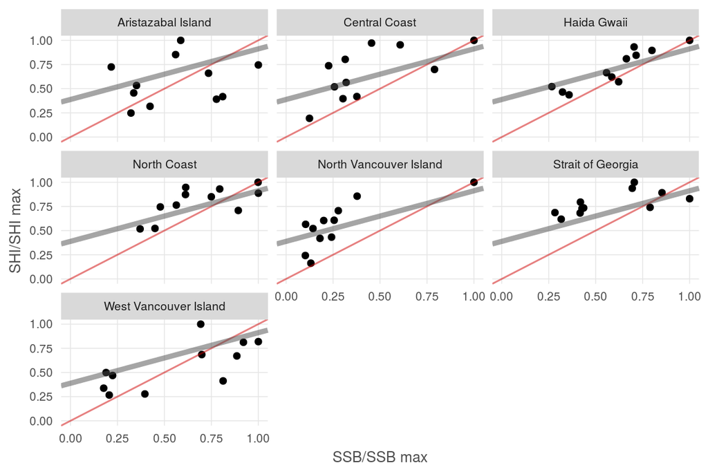

```r
ssb_shi_lm <- lm(shi_rel ~ ssb_rel, shi_ohibc_05_15)

ggplot(shi_ohibc_05_15, aes(x = ssb_rel, y = shi_rel)) +
  ggtheme_plot() +
  geom_point() +
  geom_abline(slope = 1, intercept = 0, color = 'red3', alpha = .5) +
  geom_abline(slope = ssb_shi_lm$coefficients[2], intercept = ssb_shi_lm$coefficients[1],
              color = 'grey30', size = 1.5, alpha = .5) +
  scale_x_continuous(limits = c(0, 1)) +
  scale_y_continuous(limits = c(0, 1)) +
  labs(x = 'SSB/SSB max',
       y = 'SHI/SHI max') +
  facet_wrap( ~ rgn_name)
```

```r
prov_wrapup()
```

# 4 Provenance

- *Run ID: 3 (e9f589a); run tag: “standard run”*
- *Run elapsed time: 12.381 seconds; run memory usage: 1196.6 MB*
- *System info:*
  - *System: Linux, Release: 4.4.0-57-generic. Machine: x86_64. User: ohara.*
  - *R version: R version 3.3.3 (2017-03-06), Platform: x86_64-pc-linux-gnu, Running under: Ubuntu 14.04.5 LTS.*
  - *Attached base packages: stats, graphics, grDevices, utils, datasets, methods, base*
  - *Other attached packages: XML_3.98-1.5, xml2_1.1.1, provRmd_0.1.1, stringr_1.2.0, RColorBrewer_1.1-2, dplyr_0.5.0, purrr_0.2.2, readr_1.0.0, tidyr_0.6.1, tibble_1.2, ggplot2_2.2.1, tidyverse_1.0.0, here_0.0-5*

[figure not shown]

| sequence | file_name | parent_chunk | file_dir | filetype | uncomm_chgs | commit_hash_short |
| --- | --- | --- | --- | --- | --- | --- |
| 0 | ao_herringspawn_prep.rmd | prov_footer | ~/github/ohibc/prep/ao/v2017 | parent_script | True | 50bbaa3 |
| 0 | ao_herringspawn_prep.rmd#calc_spawn_hab_index_by_rgn | calc_spawn_hab_index_by_rgn | ~/github/ohibc/prep/ao/v2017 | parent_chunk | True | 50bbaa3 |
| 0 | ao_herringspawn_prep.rmd#parse_links_from_web | parse_links_from_web | ~/github/ohibc/prep/ao/v2017 | parent_chunk | True | 50bbaa3 |
| 0 | ao_herringspawn_prep.rmd#plot_herring_spawn_by_dfo_rgn | plot_herring_spawn_by_dfo_rgn | ~/github/ohibc/prep/ao/v2017 | parent_chunk | True | 50bbaa3 |
| 0 | ao_herringspawn_prep.rmd#plot_shi_vs_ref | plot_shi_vs_ref | ~/github/ohibc/prep/ao/v2017 | parent_chunk | True | 50bbaa3 |
| 0 | ao_herringspawn_prep.rmd#prov_footer | prov_footer | ~/github/ohibc/prep/ao/v2017 | parent_chunk | True | 50bbaa3 |
| 0 | ao_herringspawn_prep.rmd#read_linked_pages_from_web | read_linked_pages_from_web | ~/github/ohibc/prep/ao/v2017 | parent_chunk | True | 50bbaa3 |
| 0 | ao_herringspawn_prep.rmd#read_xlsx_from_dfo | read_xlsx_from_dfo | ~/github/ohibc/prep/ao/v2017 | parent_chunk | True | 50bbaa3 |
| 1 | shi_links.csv | parse_links_from_web | ~/github/ohibc/prep/ao/v2017/int | output | False | 988b8c4 |
| 2 | shi_data.csv | read_linked_pages_from_web | ~/github/ohibc/prep/ao/v2017/int | output | False | 988b8c4 |

[output cut: 8 more lines]